# Become a UseR: a brief tour in R

Gregory Farage and Saunak Sen

2021-03-12

# Goals

- Why should one use/learn R?
- How to install R/Rstudio
- Learn about R basics: variables, programming, functions
- Learn about the R package ecosystem that extends its capabilities
- See a basic statistical analysis example
- Learn about additional resources

# What is R?

R is an open-source software and programming language developed as an environment for statistical computing and graphics.

## What is R?

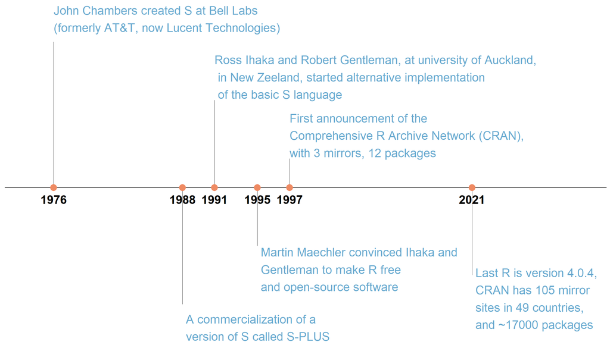

*(Generated in R with ggplot2 package)*

## What is R?

- R is a very popular tool for data analysis, statistical modeling and visualization, because it excels in statistical functions and modeling.
- In addition to the academic and research field, it is also widely used by:
  - Top tier companies (e.g., Google, Facebook, Twitter, Uber)
  - IT companies (e.g., Accenture, Capgemini, IBM, HP)
  - Financial institutions (e.g., American Express, Bank of America, Citibank)

*Ref: https://www.listendata.com/2016/12/companies-using-r.html*

# Why use the R language?

- Open source, transparent algorithms
- Reproducible data analysis
- Free of cost
- Rich package ecosystem: a large collection of tools for data analysis
- Access to advanced libraries
- Extensible by user

## Why use the R language?

- A great language to start programming:
  - A lot of written tutorial for beginners and noncoders
  - A large community that can help solve bugs or interpret package functionality

# R installation

- https://cran.r-project.org/

[figure not shown]

# A first look at R

[figure not shown]

Stories behind [R release names](https://livefreeordichotomize.com/2017/09/28/r-release-names/)

# R Studio installation

- https://rstudio.com/products/rstudio/download/

[figure not shown]

# Exploring R Studio

[figure not shown]

# R data type

A data type is a variable attribute which indicates to the R interpreter how you expect to use the variable in your program. The basic data types used in R are:

- Integer, i.e., natural numbers

```
varA <- 7L
```

- Numeric, i.e., decimal numbers and natural number

```
varB1 <- 3.14
varB2 <- 8
```

- Complex, i.e., complex number

```
varC <- 2+ 7i
```

## R data type

- Logical, i.e., boolean

```
varD1 <- TRUE
varD2 <- FALSE
```

- Character, i.e., string (text)

```
varE <- "apples"
```

# R data structure

There exists different ways to store a set of values in the computer. A specific way to organize the data set is called a data structure. In R programming, the basic data structures are:

- Vectors
- Factors
- Matrices
- Lists
- Data frames

## Vectors

- A vector is a collection of elements with identical data type.

```r
# The function c() concatenates elements to create a vector

vec1 <- c("March", "July", "September"); print(vec1)
```

```
## [1] "March"     "July"      "September"
```

```r
vec2 <- c(7, 22, 19); print(vec2)
```

```
## [1]  7 22 19
```

```r
vec3 <- c(7, "test", 19); print(vec3)
```

```
## [1] "7"    "test" "19"
```

## Factors

- A factor is a vector that is used to store categorical data.
- The categories’ labels are called levels.

```r
# Use function factor() to convert the vector into a factor
fac1 <- factor(c("A", "B", "B", "A", "D"))
fac1
```

```
## [1] A B B A D
## Levels: A B D
```

```r
# Define explicitly levels to include group C
fac2 <- factor(c("A", "B", "B", "A", "D"), levels = c("A", "B", "C", "D"))
fac2
```

```
## [1] A B B A D
## Levels: A B C D
```